# Mixed Effect Logistic Regression DrPH Sem 2

Author

Dr Hazlienor Mohd Hatta

Published

July 1, 2024

## Mixed Effect Logistic Regression

## Research Question

Rsearchers want to know what patient and physician factors are most related to whether a patient’s lung cancer goes into remission after treatment as part of a larger study of treatment outcomes and quality of life in patients with lung cancer.

## Prepare Environment

```r
library(tidyverse)
```

```
✖ purrr::%||%()   masks base::%||%()
```

```r
library(aplore3)
library(summarytools)
library(broom.mixed)
library(gee)
library(lme4)
library(sjPlot)
library(kableExtra)
library(gtsummary)
library(reshape2)
library(haven)
```

## Dataset

A variety of outcomes were collected on patients, who are nested within doctors, who are in turn nested within hospitals.

### Load data

```r
cancer <- read.csv("https://stats.idre.ucla.edu/stat/data/hdp.csv")
```

### Data exploration

```r
str(cancer)
```

```
'data.frame':   8525 obs. of  27 variables:
 $ tumorsize   : num  68 64.7 51.6 86.4 53.4 ...
 $ co2         : num  1.53 1.68 1.53 1.45 1.57 ...
 $ pain        : int  4 2 6 3 3 4 3 3 4 5 ...
 $ wound       : int  4 3 3 3 4 5 4 3 4 4 ...
 $ mobility    : int  2 2 2 2 2 2 2 3 3 3 ...
 $ ntumors     : int  0 0 0 0 0 0 0 0 2 0 ...
 $ nmorphine   : int  0 0 0 0 0 0 0 0 0 0 ...
 $ remission   : int  0 0 0 0 0 0 0 0 0 0 ...
 $ lungcapacity: num  0.801 0.326 0.565 0.848 0.886 ...
 $ Age         : num  65 53.9 53.3 41.4 46.8 ...
 $ Married     : int  0 0 1 0 0 1 1 0 1 0 ...
 $ FamilyHx    : chr  "no" "no" "no" "no" ...
 $ SmokingHx   : chr  "former" "former" "never" "former" ...
 $ Sex         : chr  "male" "female" "female" "male" ...
 $ CancerStage : chr  "II" "II" "II" "I" ...
 $ LengthofStay: int  6 6 5 5 6 5 4 5 6 7 ...
 $ WBC         : num  6088 6700 6043 7163 6443 ...
 $ RBC         : num  4.87 4.68 5.01 5.27 4.98 ...
 $ BMI         : num  24.1 29.4 29.5 21.6 29.8 ...
 $ IL6         : num  3.7 2.63 13.9 3.01 3.89 ...
 $ CRP         : num  8.086 0.803 4.034 2.126 1.349 ...
 $ DID         : int  1 1 1 1 1 1 1 1 1 1 ...
 $ Experience  : int  25 25 25 25 25 25 25 25 25 25 ...
 $ School      : chr  "average" "average" "average" "average" ...
 $ Lawsuits    : int  3 3 3 3 3 3 3 3 3 3 ...
 $ HID         : int  1 1 1 1 1 1 1 1 1 1 ...
 $ Medicaid    : num  0.606 0.606 0.606 0.606 0.606 ...
```

### Data Wrangling

```r
cancer <- cancer %>% mutate(across(where(~ is.character(.x)), as_factor))
cancer <- cancer %>% mutate(across(where(~ is.integer(.x)), as.numeric))
cancer <- cancer %>% mutate(remission = as.factor(remission))
```

```r
summary(cancer)
```

```
   tumorsize           co2             pain           wound
 Min.   : 33.97   Min.   :1.222   Min.   :1.000   Min.   :1.000
 1st Qu.: 62.49   1st Qu.:1.519   1st Qu.:4.000   1st Qu.:5.000
 Median : 70.07   Median :1.601   Median :5.000   Median :6.000
 Mean   : 70.88   Mean   :1.605   Mean   :5.473   Mean   :5.732
 3rd Qu.: 79.02   3rd Qu.:1.687   3rd Qu.:6.000   3rd Qu.:7.000
 Max.   :116.46   Max.   :2.128   Max.   :9.000   Max.   :9.000
    mobility       ntumors        nmorphine      remission  lungcapacity
 Min.   :1.00   Min.   :0.000   Min.   : 0.000   0:6004    Min.   :0.01612
 1st Qu.:5.00   1st Qu.:1.000   1st Qu.: 2.000   1:2521    1st Qu.:0.67647
 Median :6.00   Median :3.000   Median : 3.000             Median :0.81560
 Mean   :6.08   Mean   :3.066   Mean   : 3.624             Mean   :0.77409
 3rd Qu.:7.00   3rd Qu.:5.000   3rd Qu.: 5.000             3rd Qu.:0.91150
 Max.   :9.00   Max.   :9.000   Max.   :18.000             Max.   :0.99980
      Age           Married    FamilyHx     SmokingHx        Sex
 Min.   :26.32   Min.   :0.0   no :6820   former :1705   male  :3410
 1st Qu.:46.69   1st Qu.:0.0   yes:1705   never  :5115   female:5115
 Median :50.93   Median :1.0              current:1705
 Mean   :50.97   Mean   :0.6
 3rd Qu.:55.27   3rd Qu.:1.0
 Max.   :74.48   Max.   :1.0
 CancerStage  LengthofStay         WBC            RBC             BMI
 II :3409    Min.   : 1.000   Min.   :2131   Min.   :3.919   Min.   :18.38
 I  :2558    1st Qu.: 5.000   1st Qu.:5323   1st Qu.:4.802   1st Qu.:24.20
 IV : 853    Median : 5.000   Median :6007   Median :4.994   Median :27.73
 III:1705    Mean   : 5.492   Mean   :5998   Mean   :4.995   Mean   :29.07
             3rd Qu.: 6.000   3rd Qu.:6663   3rd Qu.:5.190   3rd Qu.:32.54
             Max.   :10.000   Max.   :9776   Max.   :6.065   Max.   :58.00
      IL6                CRP               DID          Experience
 Min.   : 0.03521   Min.   : 0.0451   Min.   :  1.0   Min.   : 7.00
 1st Qu.: 1.93039   1st Qu.: 2.6968   1st Qu.:100.0   1st Qu.:15.00
 Median : 3.34400   Median : 4.3330   Median :199.0   Median :18.00
 Mean   : 4.01698   Mean   : 4.9730   Mean   :203.3   Mean   :17.64
 3rd Qu.: 5.40551   3rd Qu.: 6.5952   3rd Qu.:309.0   3rd Qu.:21.00
 Max.   :23.72777   Max.   :28.7421   Max.   :407.0   Max.   :29.00
     School        Lawsuits          HID           Medicaid
 average:6405   Min.   :0.000   Min.   : 1.00   Min.   :0.1416
 top    :2120   1st Qu.:1.000   1st Qu.: 9.00   1st Qu.:0.3369
                Median :2.000   Median :17.00   Median :0.5215
                Mean   :1.866   Mean   :17.76   Mean   :0.5125
                3rd Qu.:3.000   3rd Qu.:27.00   3rd Qu.:0.7083
                Max.   :9.000   Max.   :35.00   Max.   :0.8187
```

```r
levels(cancer$CancerStage)
```

```
[1] "II"  "I"   "IV"  "III"
```

We will select variable remission as outcome and Age,Sex, Length of Stay, Experience as factor.

Level 1: subject

Level 2: Physician ID (DID)

Level 3: Hospital (HID)

```r
cancer1 <- cancer %>% select(remission, Age, Sex, LengthofStay, Experience, HID, DID)
```

## Descriptive Analysis

```r
cancer1 %>%
  select(-DID, -HID, ) %>%
  tbl_summary(by = remission,
            statistic = list(all_continuous() ~ "{mean} ({sd})"),
            digits = Age ~ c(1, 1)
             ) %>%
            modify_header(update = list(stat_1 ~ "**No Remission**",
                                        stat_2 ~ "**Remission**")) %>%
            add_overall() %>%
            add_p
```

| **Characteristic** | **Overall**, N = 8,525<sup>1</sup> | **No Remission**<sup>1</sup> | **Remission**<sup>1</sup> | **p-value**<sup>2</sup> |
| --- | --- | --- | --- | --- |
| Age | 51.0 (6.3) | 51.4 (6.3) | 50.1 (6.0) | <0.001 |
| Sex |  |  |  | 0.3 |
| male | 3,410 (40%) | 2,378 (40%) | 1,032 (41%) |  |
| female | 5,115 (60%) | 3,626 (60%) | 1,489 (59%) |  |
| LengthofStay | 5.49 (1.05) | 5.57 (1.05) | 5.31 (1.03) | <0.001 |
| Experience | 17.6 (4.1) | 17.2 (4.1) | 18.6 (3.9) | <0.001 |

<sup>1</sup> Mean (SD); n (%)  
<sup>2</sup> Wilcoxon rank sum test; Pearson’s Chi-squared test

## Marginal (Population Average) model

If the primary interest is likely in understanding the average effect of patient and physician factors across all patients within the HMO, rather than specific clusters or groups (e.g., individual hospitals or physicians), then marginal model is justified.

## Mixed Effect Logistic Regression

### Justification

While a marginal model is suitable for examining average effects across the entire patient population, it may overlook potential variability and heterogeneity within subgroups or clusters (e.g., variations in treatment outcomes (remission) across different hospitals or physician practices).

There is strong evidence of clustering or hierarchical effects (e.g., certain physicians/hospital consistently achieve higher remission rates), a mixed-effects model is more appropriate to account for such variability.

By incorporating random effects, mixed-effects models can account for the correlation among patients treated by the same physician or within the same hospital.

By capturing within-cluster correlations and variability, mixed-effects models can improve the precision of estimates and increase statistical power compared to marginal models that assume independence among observations.

### Estimation

doctor level predictor: experience

random intercept: physician (DID)

#### Random Intercept Model

```r
mlm1 <- glmer(remission ~ Age + Sex +  LengthofStay + Experience +
                        (1 | DID), family = binomial, control = glmerControl                         (optimizer = "bobyqa"), nAGQ = 20,
                        data = cancer1)
```

```r
summary(mlm1)
```

```
Generalized linear mixed model fit by maximum likelihood (Adaptive
  Gauss-Hermite Quadrature, nAGQ = 20) [glmerMod]
 Family: binomial  ( logit )
Formula: remission ~ Age + Sex + LengthofStay + Experience + (1 | DID)
   Data: cancer1
Control: glmerControl(optimizer = "bobyqa")

     AIC      BIC   logLik deviance df.resid
  7686.6   7728.9  -3837.3   7674.6     8519

Scaled residuals:
    Min      1Q  Median      3Q     Max
-3.5283 -0.4678 -0.2172  0.4509  4.8180

Random effects:
 Groups Name        Variance Std.Dev.
 DID    (Intercept) 3.773    1.942
Number of obs: 8525, groups:  DID, 407

Fixed effects:
              Estimate Std. Error z value Pr(>|z|)
(Intercept)  -0.412164   0.545898  -0.755    0.450
Age          -0.032633   0.005535  -5.896 3.73e-09 ***
Sexfemale    -0.059825   0.062809  -0.952    0.341
LengthofStay -0.260276   0.033008  -7.885 3.14e-15 ***
Experience    0.118239   0.026514   4.459 8.22e-06 ***
---
Signif. codes:  0 '***' 0.001 '**' 0.01 '*' 0.05 '.' 0.1 ' ' 1

Correlation of Fixed Effects:
            (Intr) Age    Sexfml LngthS
Age         -0.361
Sexfemale   -0.071  0.007
LengthofSty -0.095 -0.424 -0.001
Experience  -0.856 -0.012 -0.001 -0.012
```

#### Random Intercept+Slope Model

```r
mlm2 <- glmer(remission ~ Age + Sex +  LengthofStay + Experience +
                        (1 + LengthofStay | DID), family = binomial,                                  glmerControl(calc.derivs = FALSE),
                        data = cancer1)
```

```r
summary(mlm2)
```

```
Generalized linear mixed model fit by maximum likelihood (Laplace
  Approximation) [glmerMod]
 Family: binomial  ( logit )
Formula:
remission ~ Age + Sex + LengthofStay + Experience + (1 + LengthofStay |
    DID)
   Data: cancer1
Control: glmerControl(calc.derivs = FALSE)

     AIC      BIC   logLik deviance df.resid
  7679.4   7735.8  -3831.7   7663.4     8517

Scaled residuals:
    Min      1Q  Median      3Q     Max
-3.0694 -0.4671 -0.2100  0.4610  4.7056

Random effects:
 Groups Name         Variance Std.Dev. Corr
 DID    (Intercept)  1.24680  1.1166
        LengthofStay 0.07216  0.2686   0.12
Number of obs: 8525, groups:  DID, 407

Fixed effects:
              Estimate Std. Error z value Pr(>|z|)
(Intercept)   0.254243   0.509001   0.499    0.617
Age          -0.032404   0.005456  -5.939 2.87e-09 ***
Sexfemale    -0.055318   0.061988  -0.892    0.372
LengthofStay -0.360293   0.036107  -9.978  < 2e-16 ***
Experience    0.107825   0.024321   4.433 9.28e-06 ***
---
Signif. codes:  0 '***' 0.001 '**' 0.01 '*' 0.05 '.' 0.1 ' ' 1

Correlation of Fixed Effects:
            (Intr) Age    Sexfml LngthS
Age         -0.389
Sexfemale   -0.078  0.007
LengthofSty -0.119 -0.383 -0.001
Experience  -0.852 -0.005  0.002  0.017
```

#### Model Comparison

```r
anova(mlm1, mlm2, test='Chisq')
```

```
Data: cancer1
Models:
mlm1: remission ~ Age + Sex + LengthofStay + Experience + (1 | DID)
mlm2: remission ~ Age + Sex + LengthofStay + Experience + (1 + LengthofStay | DID)
     npar    AIC    BIC  logLik deviance  Chisq Df Pr(>Chisq)
mlm1    6 7686.6 7728.9 -3837.3   7674.6
mlm2    8 7679.4 7735.8 -3831.7   7663.4 11.124  2   0.003842 **
---
Signif. codes:  0 '***' 0.001 '**' 0.01 '*' 0.05 '.' 0.1 ' ' 1
```

The AIC of model with random slope is lower than the model with random intercept only. Improvement in model fit by adding random slope in model **mlm2** is statistically significant (p-value <0.05). Given the significant p-value, we would reject the null hypothesis that the simpler model **(mlm1)** is sufficient and prefer the more complex model (**mlm2**).

Preliminary final model: **mlm2**

### **Inference**

log odds

```r
lo_mlm2 <-tidy(mlm2, conf.int = T)
lo_mlm2 <- lo_mlm2 %>% select(term, estimate,conf.low, conf.high )
lo_mlm2
```

```
# A tibble: 8 × 4
  term                          estimate conf.low conf.high
  <chr>                            <dbl>    <dbl>     <dbl>
1 (Intercept)                     0.254   -0.743     1.25
2 Age                            -0.0324  -0.0431   -0.0217
3 Sexfemale                      -0.0553  -0.177     0.0662
4 LengthofStay                   -0.360   -0.431    -0.290
5 Experience                      0.108    0.0602    0.155
6 sd__(Intercept)                 1.12    NA        NA
7 cor__(Intercept).LengthofStay   0.123   NA        NA
8 sd__LengthofStay                0.269   NA        NA
```

```r
or_mlm2 <- tidy(mlm2, exponentiate = T, conf.int = T)
or_mlm2 <- or_mlm2 %>%  select(estimate,conf.low, conf.high , p.value)
or_mlm2
```

```
# A tibble: 8 × 4
  estimate conf.low conf.high   p.value
     <dbl>    <dbl>     <dbl>     <dbl>
1    1.29     0.476     3.50   6.17e- 1
2    0.968    0.958     0.979  2.87e- 9
3    0.946    0.838     1.07   3.72e- 1
4    0.697    0.650     0.749  1.90e-23
5    1.11     1.06      1.17   9.28e- 6
6    1.12    NA        NA     NA
7    0.123   NA        NA     NA
8    0.269   NA        NA     NA
```

```r
res_mlm2 <- cbind(lo_mlm2, or_mlm2)
colnames(res_mlm2) <- c('term', 'b', 'lower 95% b','upper 95% b', 'OR',
                            'lower 95% or' , 'upper b95% or', 'p-value')
res_mlm2
```

```
                           term           b lower 95% b upper 95% b        OR
1                   (Intercept)  0.25424334 -0.74338011  1.25186678 1.2894855
2                           Age -0.03240438 -0.04309892 -0.02170984 0.9681150
3                     Sexfemale -0.05531810 -0.17681140  0.06617521 0.9461841
4                  LengthofStay -0.36029347 -0.43106258 -0.28952436 0.6974716
5                    Experience  0.10782463  0.06015628  0.15549299 1.1138524
6               sd__(Intercept)  1.11660398          NA          NA 1.1166040
7 cor__(Intercept).LengthofStay  0.12335723          NA          NA 0.1233572
8              sd__LengthofStay  0.26863536          NA          NA 0.2686354
  lower 95% or upper b95% or      p-value
1    0.4755039     3.4968648 6.174308e-01
2    0.9578166     0.9785241 2.873328e-09
3    0.8379378     1.0684139 3.721748e-01
4    0.6498182     0.7486196 1.895041e-23
5    1.0620025     1.1682337 9.276306e-06
6           NA            NA           NA
7           NA            NA           NA
8           NA            NA           NA
```

### Prediction

extract fixed effect

```r
fixef(mlm2)
```

```
 (Intercept)          Age    Sexfemale LengthofStay   Experience
  0.25424334  -0.03240438  -0.05531810  -0.36029347   0.10782463
```

extract random effect

```r
head(ranef(mlm2), 3)
```

```
$DID
     (Intercept)  LengthofStay
1   -1.277006675 -0.3339620036
2    0.120632686  0.2162309498
3    0.501598585  0.2375670616
4    0.305391535  0.0178718576
5   -0.865320548 -0.2304602377
6   -0.612538640 -0.1577712798
7   -0.589631831 -0.1240418984
8   -1.116081456 -0.2990579454
9   -0.780150356 -0.2196252027
10  -0.225839398  0.0978165542
11  -0.160928466  0.2215953262
12  -0.327058224 -0.1046520291
13   0.600563942 -0.0400988851
```

[output cut: 394 more lines]

```r
head(predict(mlm2, type = 'link'), 10)
```

```
        1         2         3         4         5         6         7         8
-4.597936 -4.295150 -3.582429 -3.138931 -4.009219 -3.481164 -2.903791 -3.307245
        9        10
-4.255134 -4.824804
```

manual calculation for 1st observation

```r
cancer1[1,]
```

```
  remission      Age  Sex LengthofStay Experience HID DID
1         0 64.96824 male            6         25   1   1
```

```r
 (0.25424334) + (-1.277006675) + (-0.03240438*64.96824) + (-0.05531810*0 ) + (-0.36029347*6) + (0.10782463*25) + (-0.3339620036*6)
```

```
[1] -4.597936
```

predict probability for first 10 observation

```r
head(predict(mlm2, type = 'response'), 10)
```

```
          1           2           3           4           5           6
0.009972161 0.013451130 0.027055699 0.041529665 0.017824100 0.029852962
          7           8           9          10
0.051966464 0.035323478 0.013992620 0.007964192
```

manual calculation for 1st observation

```r
exp(-4.597936)/(1+exp(-4.597936))
```

```
[1] 0.009972159
```

## Model fitness

AUROC

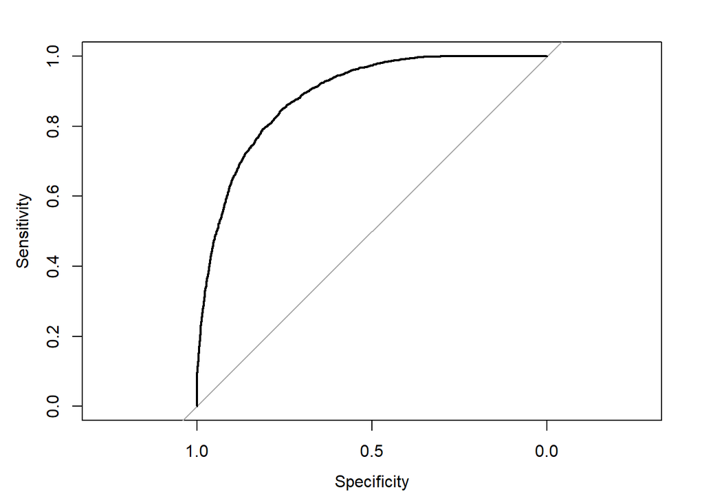

```r
library(pROC)
roc <- roc(response = cancer1$remission, predictor = fitted(mlm2))
plot(roc)
```

```r
auc(roc)
```

```
Area under the curve: 0.8878
```

```r
ci(roc)
```

```
95% CI: 0.8808-0.8948 (DeLong)
```

model performance

```r
library(caret)
remission <- factor(cancer1$remission, levels = c("0", "1"))

fit.m <- augment(mlm2, type.predict = 'response') |>
           mutate(pred.class = factor(ifelse(.fitted > 0.5, '1', '0')))
fit.m$pred.class <- factor(fit.m$pred.class, levels = levels(remission))

confusionMatrix(data = fit.m$pred.class, reference = remission)
```

```
Confusion Matrix and Statistics

          Reference
Prediction    0    1
         0 5453  962
         1  551 1559

               Accuracy : 0.8225
                 95% CI : (0.8142, 0.8306)
    No Information Rate : 0.7043
    P-Value [Acc > NIR] : < 2.2e-16

                  Kappa : 0.5528

 Mcnemar's Test P-Value : < 2.2e-16

            Sensitivity : 0.9082
            Specificity : 0.6184
         Pos Pred Value : 0.8500
         Neg Pred Value : 0.7389
             Prevalence : 0.7043
         Detection Rate : 0.6396
   Detection Prevalence : 0.7525
      Balanced Accuracy : 0.7633

       'Positive' Class : 0
```

## Data Presentation

#### Table

log odd

```r
tbl_regression(mlm2, estimate_fun = function(x) style_number(x, digits = 3))
```

| **Characteristic** | **log(OR)**<sup>1</sup> | **95% CI**<sup>1</sup> | **p-value** |
| --- | --- | --- | --- |
| Age | -0.032 | -0.043, -0.022 | <0.001 |
| Sex |  |  |  |
| male | — | — |  |
| female | -0.055 | -0.177, 0.066 | 0.4 |
| LengthofStay | -0.360 | -0.431, -0.290 | <0.001 |
| Experience | 0.108 | 0.060, 0.155 | <0.001 |

<sup>1</sup> OR = Odds Ratio, CI = Confidence Interval

odd

```r
tbl_regression(mlm2, exp = T, estimate_fun = function(x) style_number(x, digits = 3))
```

| **Characteristic** | **OR**<sup>1</sup> | **95% CI**<sup>1</sup> | **p-value** |
| --- | --- | --- | --- |
| Age | 0.968 | 0.958, 0.979 | <0.001 |
| Sex |  |  |  |
| male | — | — |  |
| female | 0.946 | 0.838, 1.068 | 0.4 |
| LengthofStay | 0.697 | 0.650, 0.749 | <0.001 |
| Experience | 1.114 | 1.062, 1.168 | <0.001 |

<sup>1</sup> OR = Odds Ratio, CI = Confidence Interval

Or

```r
tab_model(mlm2)
```

|  | remission |  |  |
| --- | --- | --- | --- |
| Predictors | Odds Ratios | CI | p |
| (Intercept) | 1.29 | 0.48 – 3.50 | 0.617 |
| Age | 0.97 | 0.96 – 0.98 | **<0.001** |
| Sex [female] | 0.95 | 0.84 – 1.07 | 0.372 |
| LengthofStay | 0.70 | 0.65 – 0.75 | **<0.001** |
| Experience | 1.11 | 1.06 – 1.17 | **<0.001** |
| Random Effects |  |  |  |
| σ<sup>2</sup> | 3.29 |  |  |
| τ<sub>00</sub> <sub>DID</sub> | 1.25 |  |  |
| τ<sub>11</sub> <sub>DID.LengthofStay</sub> | 0.07 |  |  |
| ρ<sub>01</sub> <sub>DID</sub> | 0.12 |  |  |
| ICC | 0.54 |  |  |
| N <sub>DID</sub> | 407 |  |  |
| Observations | 8525 |  |  |
| Marginal R<sup>2</sup> / Conditional R<sup>2</sup> | 0.058 / 0.569 |  |  |

#### Plot

Plot marginal effect

```
Data were 'prettified'. Consider using `terms="Age [all]"` to get smooth
  plots.
```

```
Data were 'prettified'. Consider using `terms="Experience [all]"` to get
  smooth plots.
```

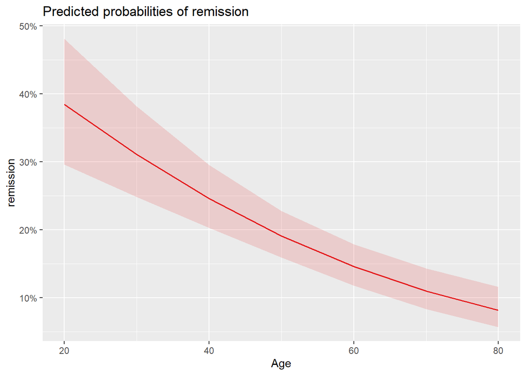

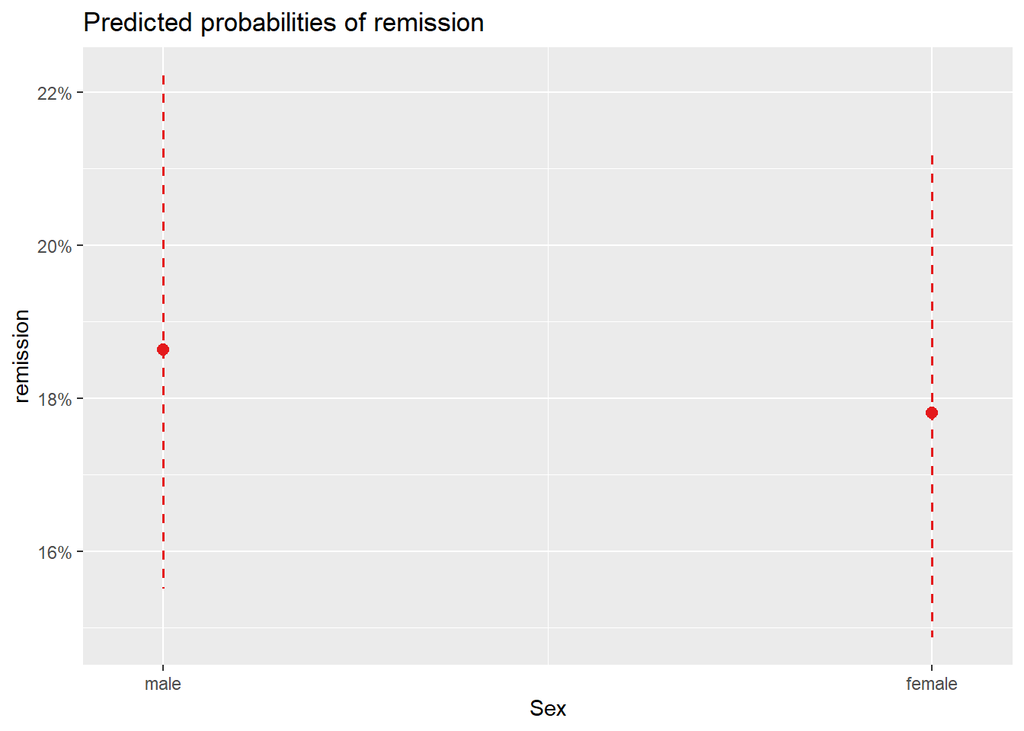

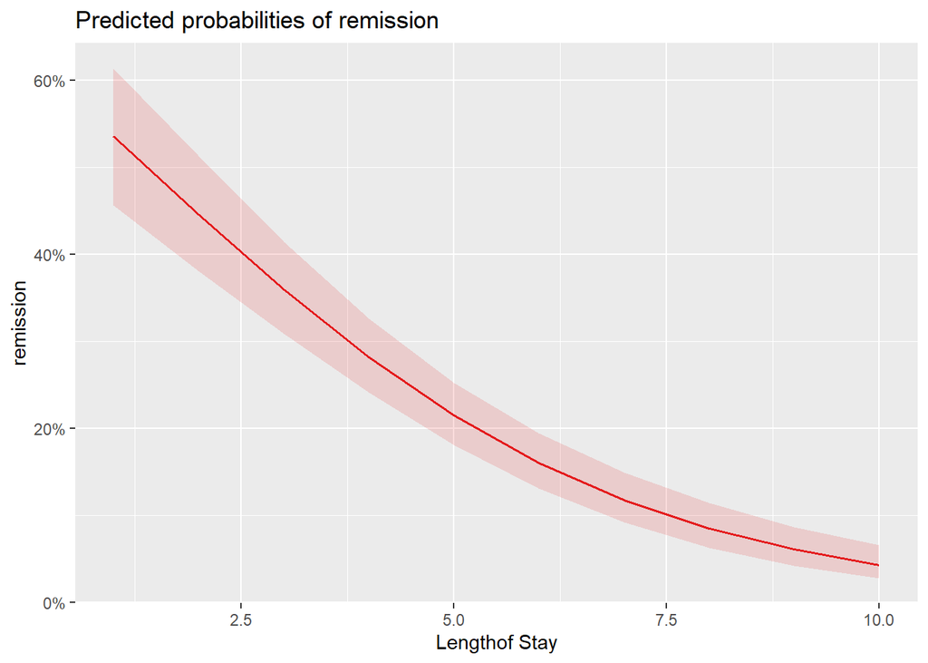

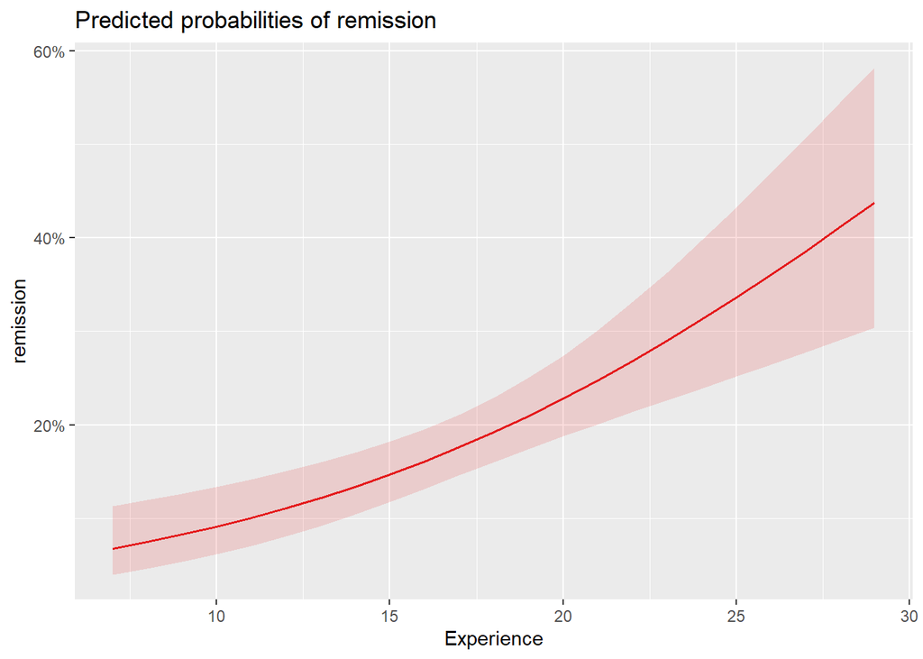

```r
plot_model(mlm2, type = "pred")
```

Plot random effect

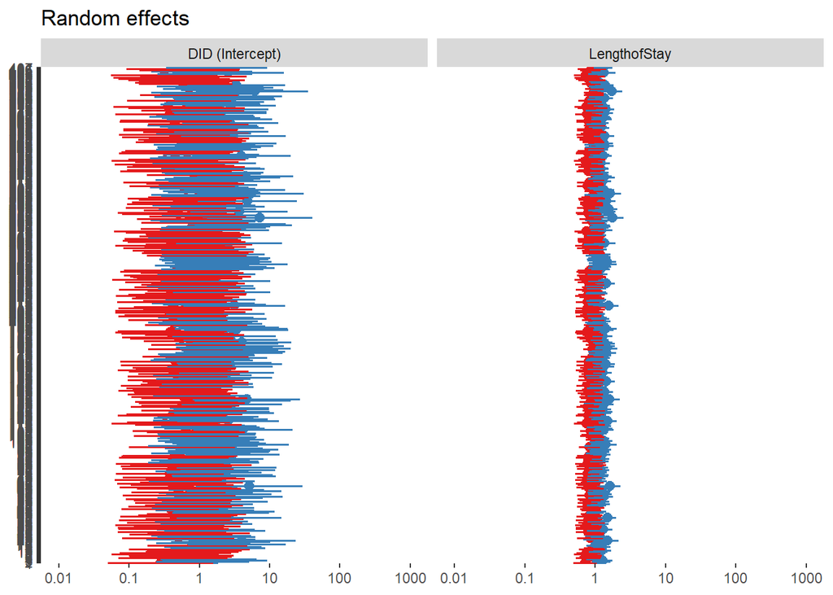

```r
plot_model(mlm2, type = 're')
```

Or

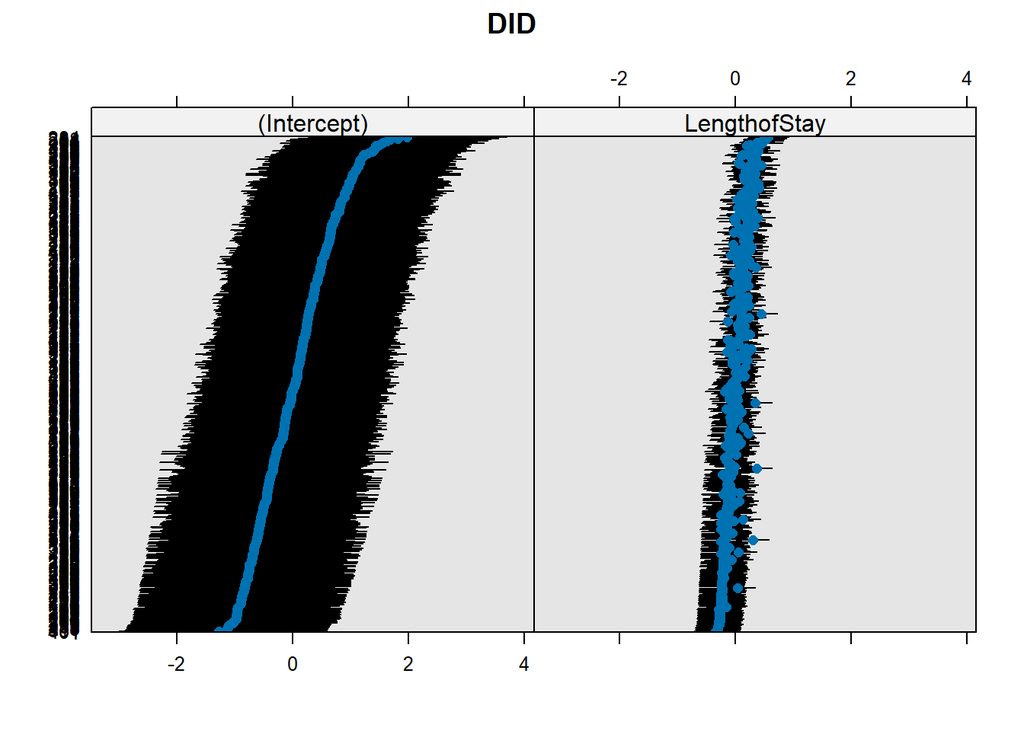

```r
lattice::dotplot(ranef(mlm2, which = "DID", condVar = TRUE))
```

#### Interpretation

For each year increase in age, the odds of remission in lung cancer patient decrease by a factor of 0.968 (95% CI: 0.958, 0.979;p-value <0.001), when adjusted for sex, length of stay, physician experience, and random effect of physician and length of stay.

Being female is associated with a 0.946 times the odd (95% CI: 0.838, 1.068, p-value:0.372) to achieve remission in lung cancer compared to male, when adjusted for age, length of stay, physician experience, and random effect of physician and length of stay.

The analysis demonstrated variability in the association between length of stay on remission across different physician.

The effect of length of stay varies slightly across different DIDs, indicating some physicians might have different length of stay effects on remission.